# Présentation

## Introduction

Etude de données transcriptomiques sur le Myélome Multiple, issues du **MMRF COMMPASS**.

Le travail se portera sur 4 gènes d’intérêt : **GJA1**, **SORT1**, **NTRK2** et **NTRK3**.

Un des objectifs est de trouver les gènes co-régulés à nos gènes d’intérêt grâce à différents *clustering hiérarchique*.

### Présentation des données

Les données de 787 patients ont été récupérées sur le site du GDC Data Portal. 72 individus présentent différents échantillons (entre 2 et 5) pour un total de **859 échantillons**. Les fichiers de données transcriptomiques comportent les valeurs d’expression de **60 660** gènes. Des données cliniques ont également été récupérées afin de caractériser le profil des patients.

Différentes quantifications étaients disponibles : *unstranded*, *stranded-first*, *stranded-second*, *TPM*, *FPKM* et *FPKM-UQ*. Nous avons choisi de travailler sur les données **TPM**.

Nous avons réduis le nombre de gènes à **19 962** en ne gardant que les gènes codant pour des protéines (**protein-coding**) puis à **19 515** en enlevant les gènes d’expression nulle. Les expressions ont été log2 transformées (log2(TPM + 1)) afin de réduire l’impact des valeurs extrêmes.

### Récapitulatif

| Nb.Individus | Nb.Échantillons | Nb.Gènes | Gènes.d.intérêt |
| --- | --- | --- | --- |
| 787 | 859 | 19515 | SORT1 + GJA1 + NTRK2 + NTRK3 |

### Logiciels et type des données

Le langage de programmation **R** a été utilisé afin de réaliser toutes les démarches statistiques (clustering, graphiques,…). Le logiciel **Visual Studio Code** a également été utilisé afin d’observer les fichiers ainsi que pour faire un premier nettoyage des fichiers de données cliniques (parfois volumineux).

Concernant le clustering hiérarchique, les packages *cluster*, *dendextend*, *pheatmap* ont été utilisés afin de réaliser les clustering et d’observer les résultats (dendogrammes et heatmaps).

Les fichiers (gène et cliniques) étaient au format **tsv** et ont été chargés en utilisant le package *readr* (interface Rstudio).

### Feuille de Route

Le travail a débuté par la récupération des données (génétique et clinique) sur le site du GDC Data Portal, grâce notamment aux outils **Cohort Builder** et **Data Transfer Tool**.

Les données cliniques ont ensuite été nettoyées et transformées afin d’observer les profils des patients : Suppression des variables sans observation (ou en contenant très peu); Recodage de certaines variables en catégories (âge); Transformation des modalités de certaines variables (regroupement de modalités redondantes).

Les données transcriptomiques ont quant à elles été nettoyées (suppression de lignes contenant des identifiants) et regroupées en un seul jeu de données. Les identifiants Ensembl ont été remplacés par les noms de gènes (pour une meilleure lisibilité). Ils ont cependant été utilisés afin de comparer des gènes redondants dans les données (noms identiques mais identifiants différents). La majorité de ces gènes correspondait à des gènes d’expression nulle (qui ont été retirés ultérieurement) tandis que les gènes restants ne figurent pas dans les gènes analysés par clustering.

# Clustering

Pour le clustering, nous avons choisi de transformer les données en **standardisant** les valeurs d’expression des gènes (**z-score**). Nous avons ensuite appliqué un *clustering hiérarchique* sur les données standardisées.

### Méthodologie

Nous allons comparer les résultats de plusieurs clustering hiérarchique en utilisant différentes méthodes de distance (4) et de dissimilarité (6). Nous allons également visualiser les résultats à l’aide de dendrogrammes et de heatmaps.

| Distance | Euclidienne | Manhattan.Maximum.Canberra |
| --- | --- | --- |
| Dissimilarité | Ward.D2 + Ward.D + Average + Single + Complete + Mcquitty | Average + Single + Complete + Mcquitty |

### Résultats Silhouette (Qualité clustering)

| Linkage | Distance | Silhouette_Score | Optimal_k |
| --- | --- | --- | --- |
| mcquitty | maximum | 0.4378992 | 2 |
| average | maximum | 0.4281839 | 3 |
| complete | euclidean | 0.3434793 | 4 |
| ward.D2 | euclidean | 0.3428027 | 3 |
| average | euclidean | 0.3426938 | 4 |
| mcquitty | euclidean | 0.3426938 | 4 |
| ward.D | euclidean | 0.3410119 | 3 |
| average | manhattan | 0.3396025 | 2 |
| complete | manhattan | 0.3396025 | 2 |
| mcquitty | manhattan | 0.3396025 | 2 |
| complete | maximum | 0.3394818 | 2 |
| single | manhattan | 0.2998725 | 3 |
| single | maximum | 0.2673367 | 2 |
| average | canberra | 0.2456916 | 2 |
| complete | canberra | 0.2456916 | 2 |
| mcquitty | canberra | 0.2456916 | 2 |
| single | euclidean | 0.2326849 | 4 |
| single | canberra | 0.1993812 | 2 |

*La silhouette est comprise entre* $[0, 1]$ *et quantifie la qualité du clustering (proche de 1* $↔︎$ *clustering de bonne qualité).*

### Choix des gènes

La grande dimensionnalité des données nous a poussé à réduire le nombre de gènes étudiés. Ainsi nous avons choisi de ne garder que les gènes dont la corrélation absolue (par rapport à nos gènes d’intérêt) est supérieure à 0.5.

|  | Gène |
| --- | --- |
| 1 | ABHD12 |
| 2 | ACHE |
| 3 | ACKR4 |
| 4 | ADGRA2 |
| 5 | AGMAT |
| 6 | AL160272.2 |
| 7 | ANG |
| 8 | APBA2 |
| 9 | APLNR |
| 10 | ATP13A2 |

[output cut: 148 more lines]

#### Récapitulatif

| Nombre.de.gènes.original | Nombre.de.gènes.clustering |
| --- | --- |
| 19515 | 158 |

# Euclidean

## Heatmaps et Dendrogrammes

### Average

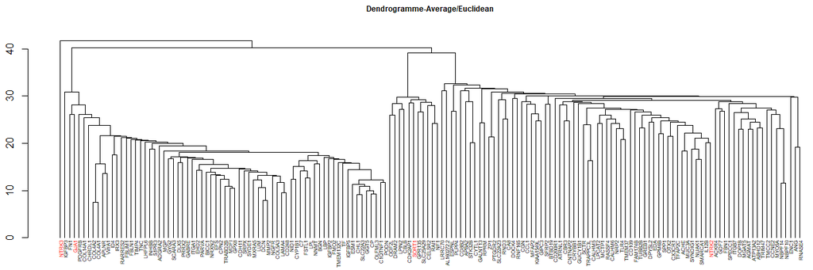

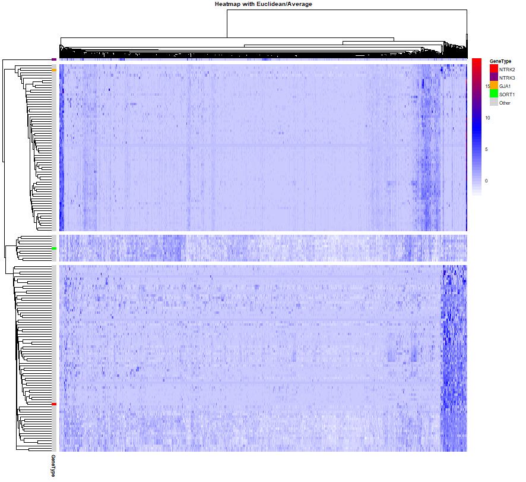

### Complete

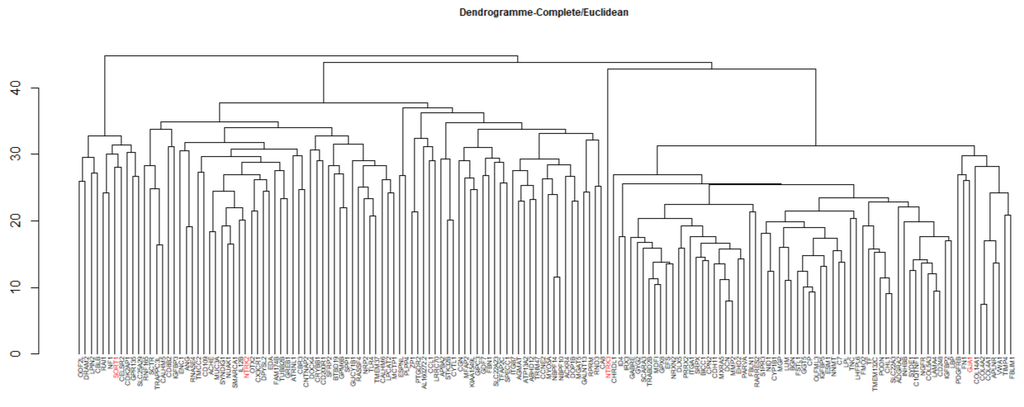

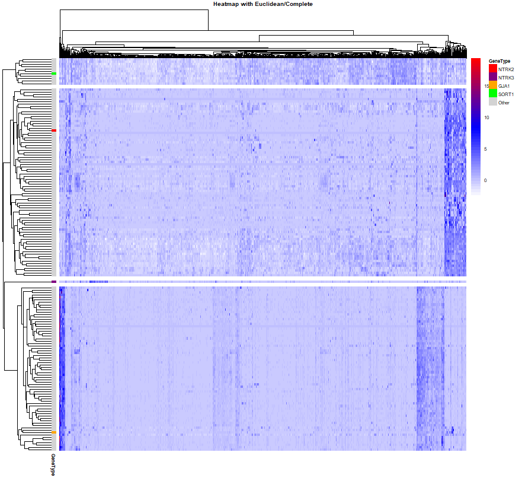

### Single

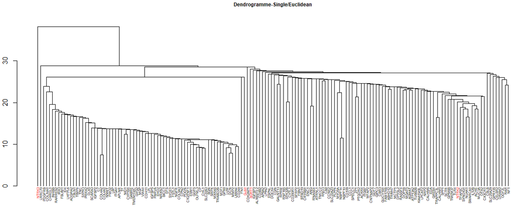

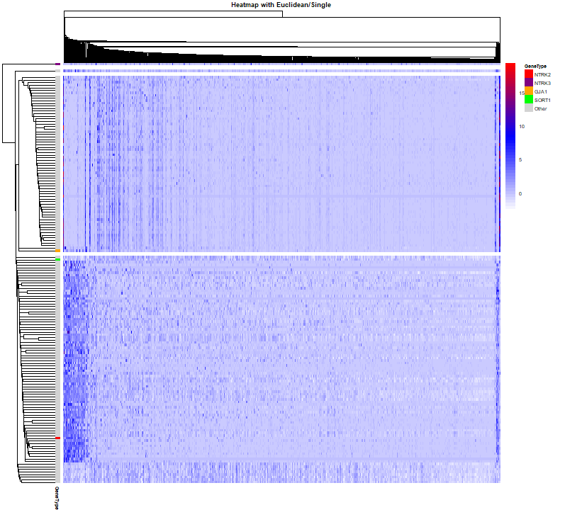

### Mcquitty

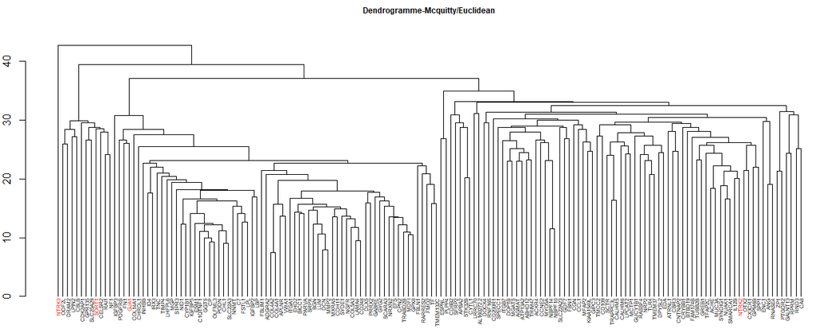

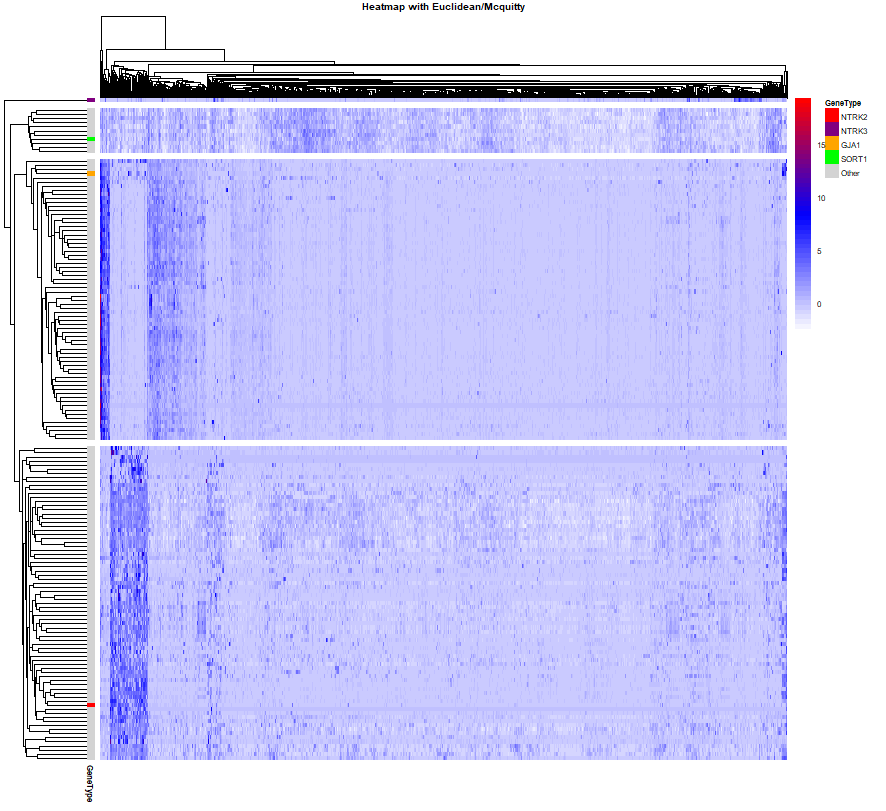

### Ward.D2

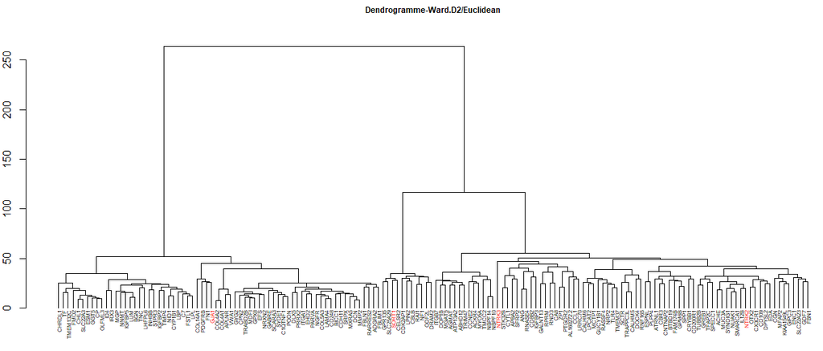

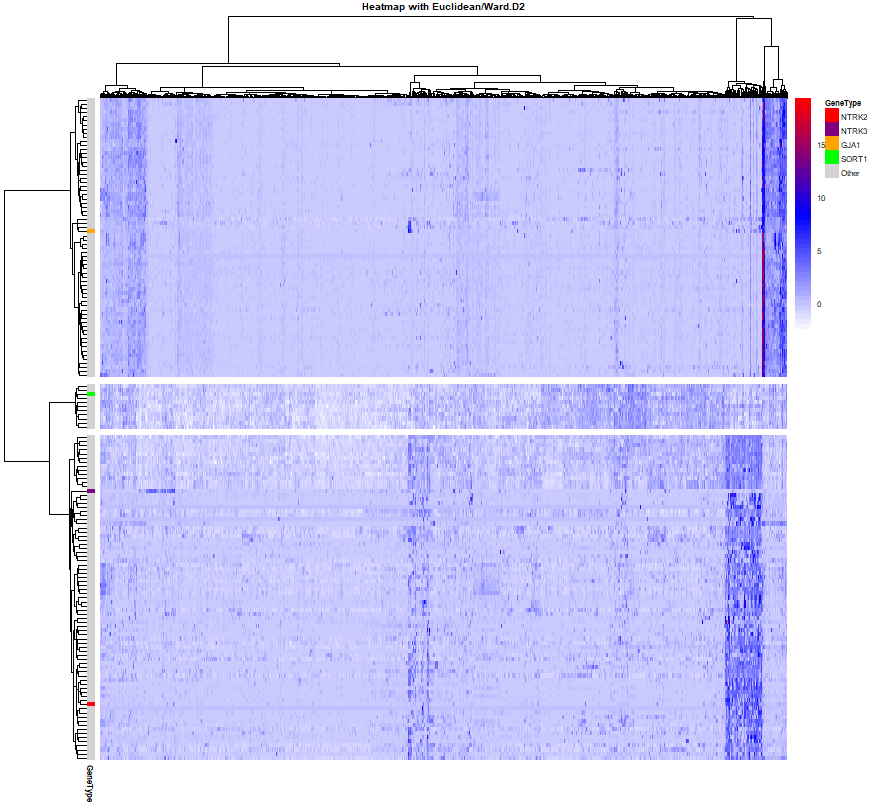

### Ward.D

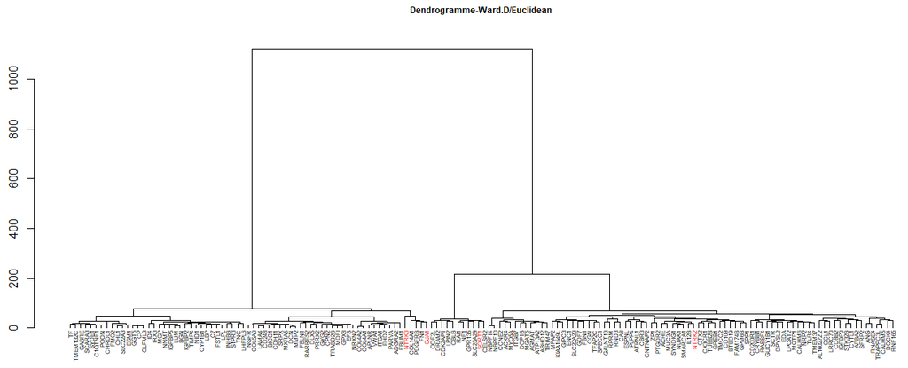

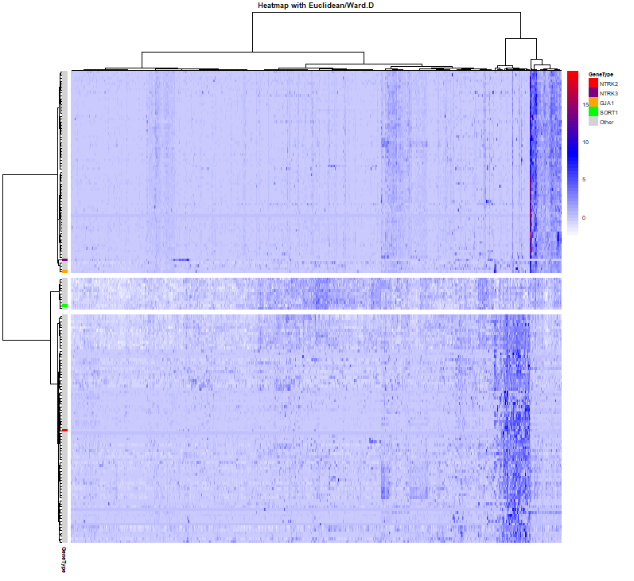

# Maximum

## Heatmaps et Dendrogrammes

### Average

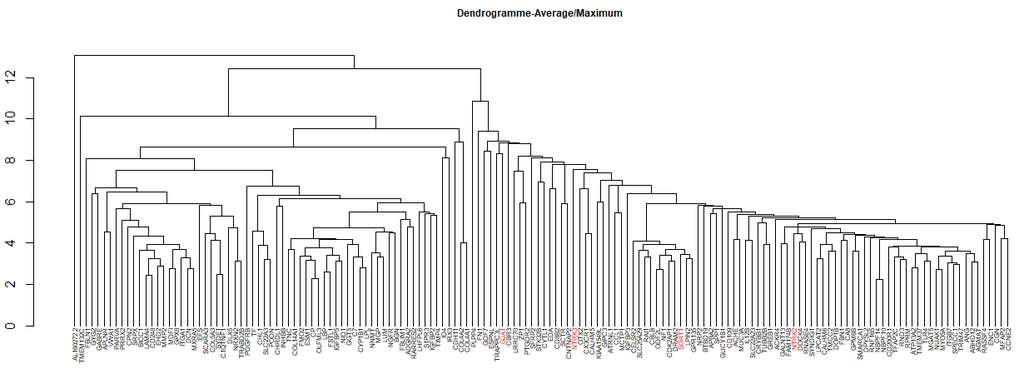

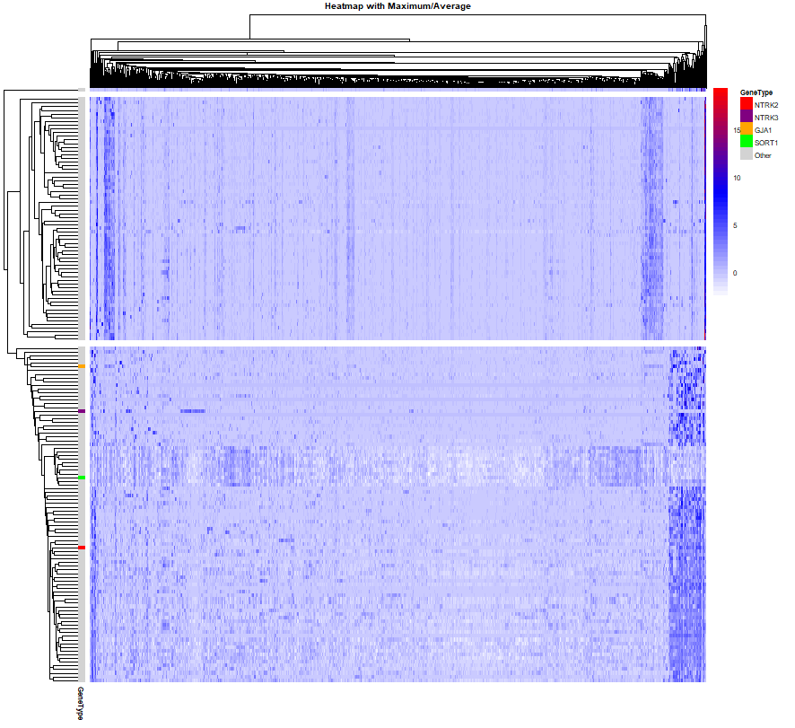

### Complete

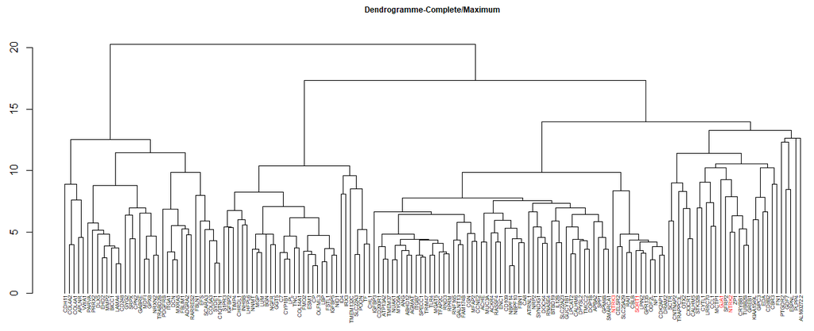

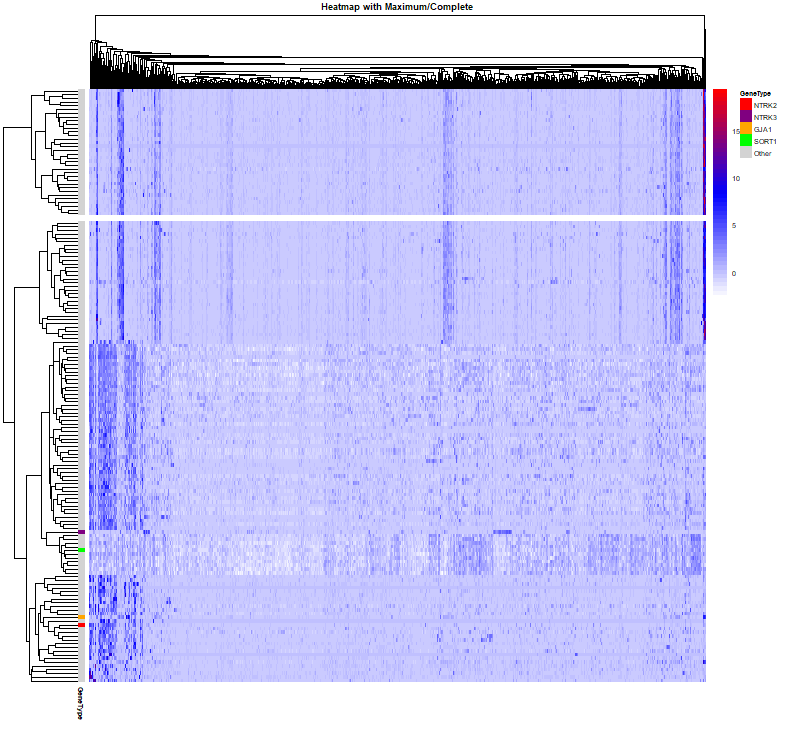

### Single

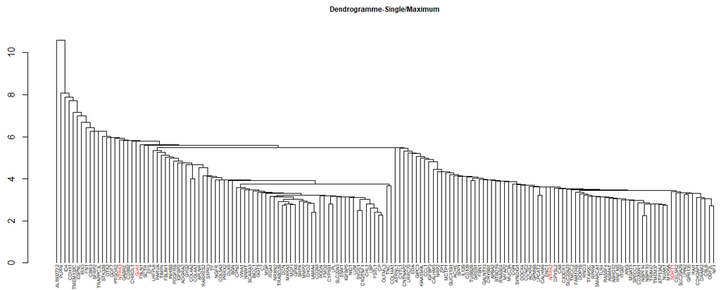

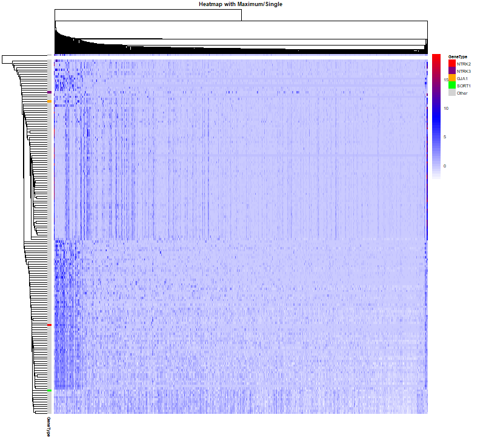

### Mcquitty

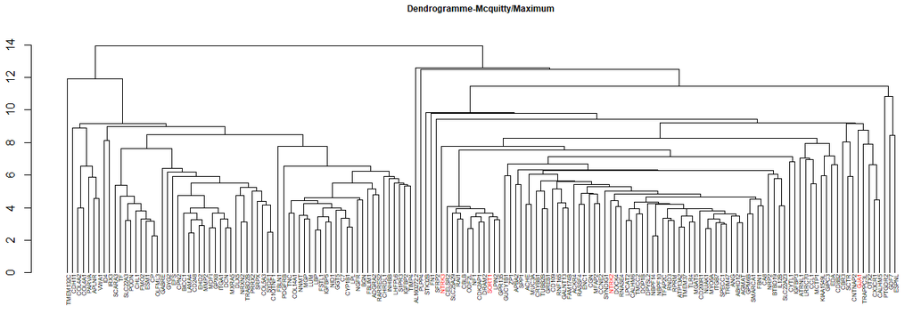

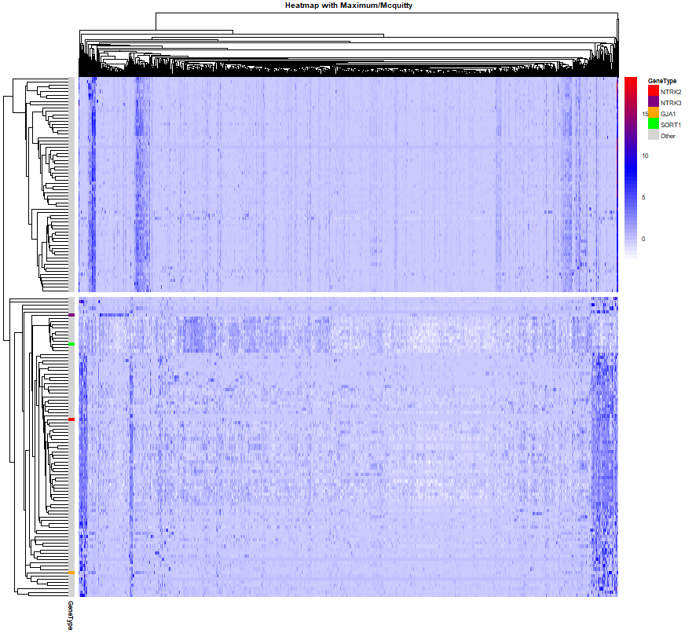

# Manhattan

## Heatmaps et Dendrogrammes

### Average

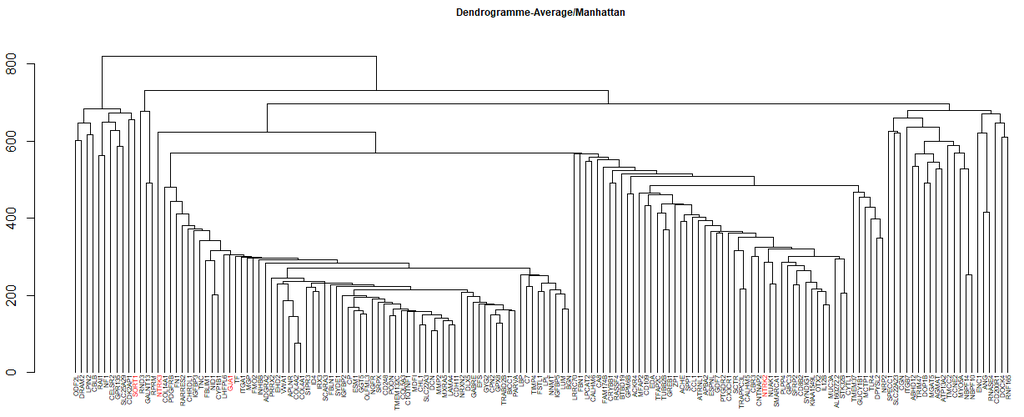

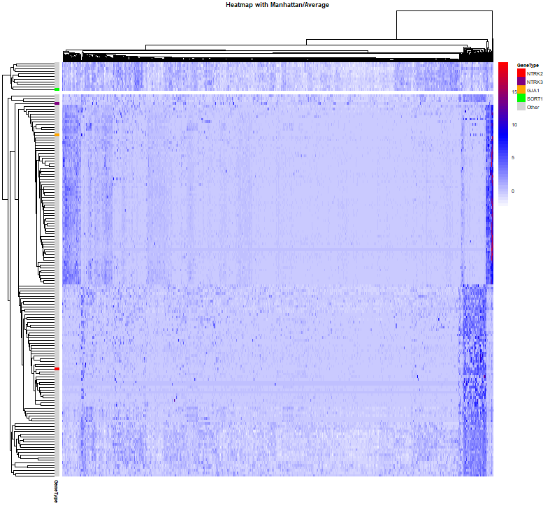

### Complete

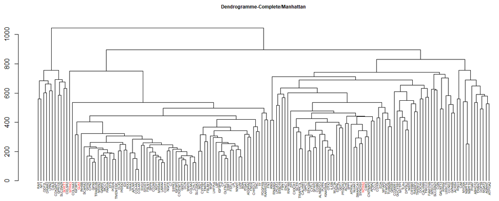

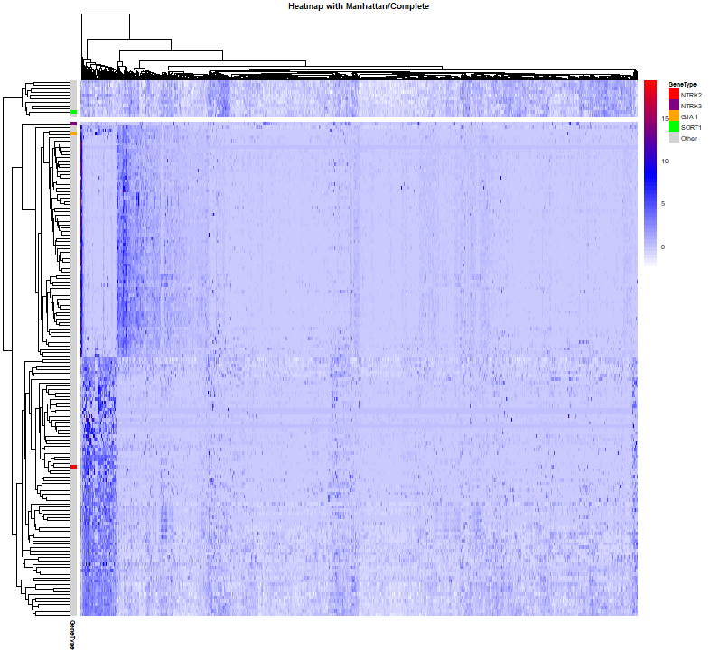

### Single

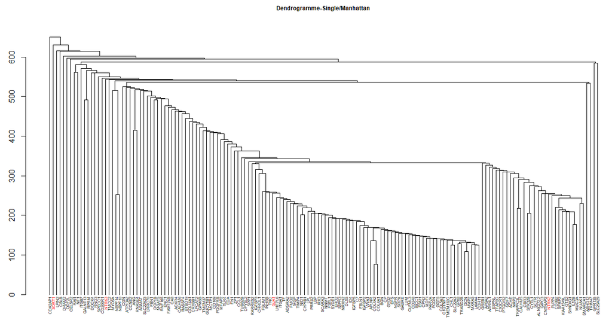

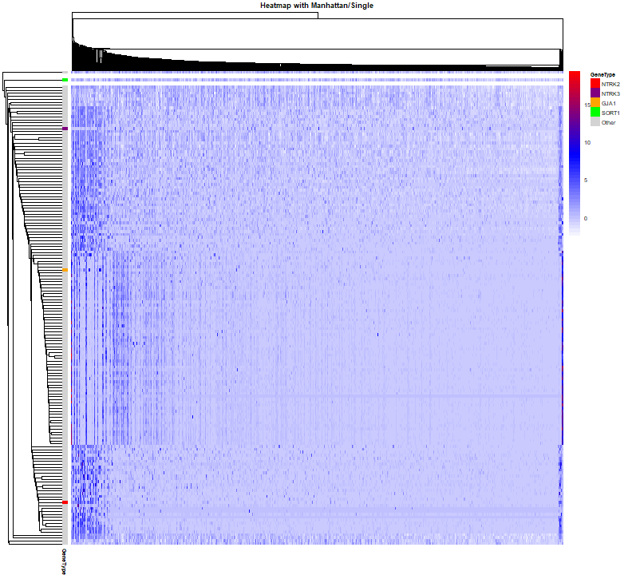

### Mcquitty

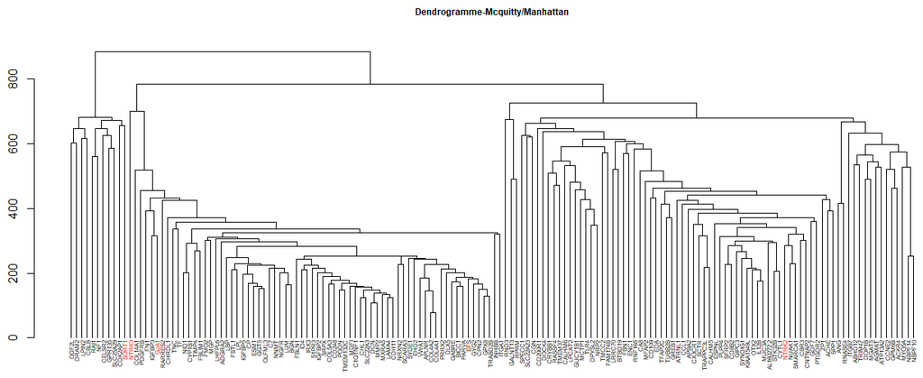

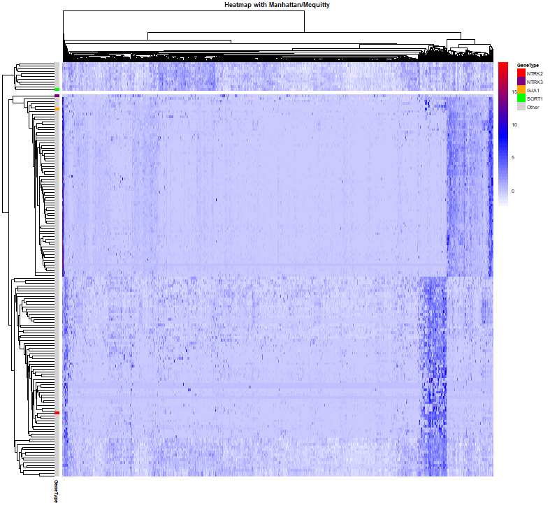

# Canberra

## Heatmaps et Dendrogrammes

### Average

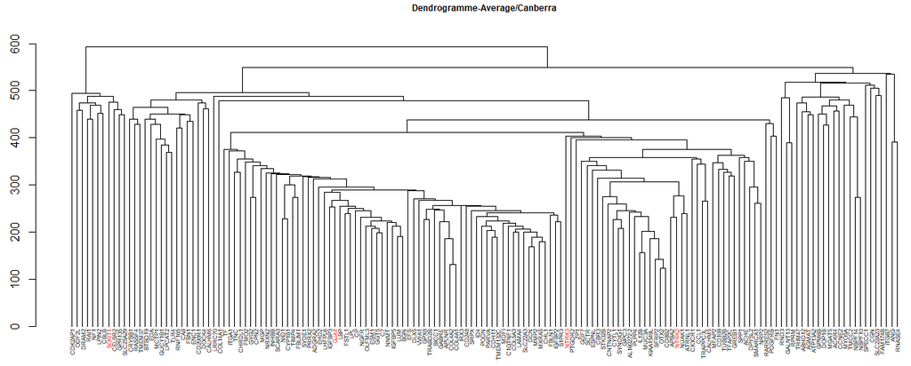

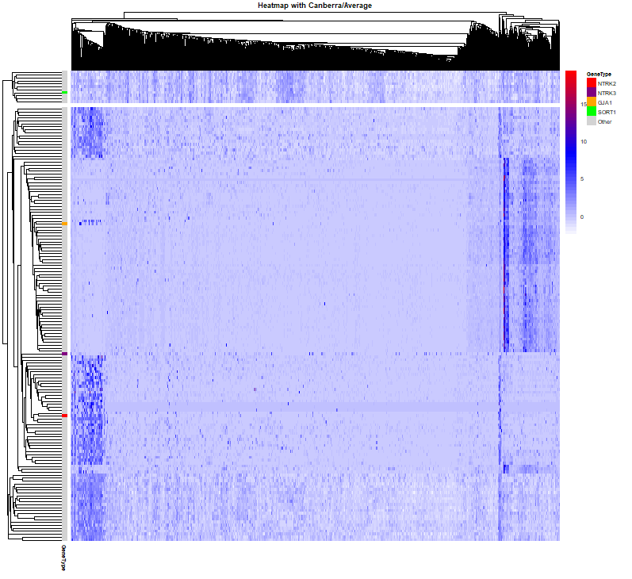

### Complete

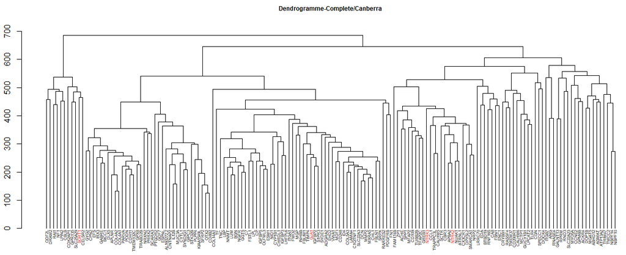

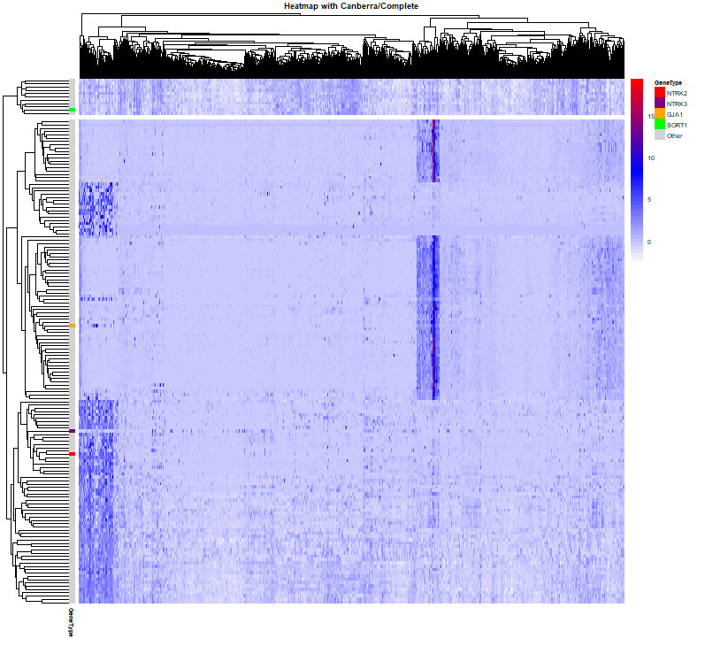